# Measuring Naturalistic Speech Comprehension

Irmak Ergin

2024-03-21 15:15:19.809555

# 1 Introduction

Speech comprehension has been described as an effortless, robust, and automatic process (Shannon et al., 1995; Gwilliams & Davis, 2022). Yet, in real-world contexts, it is common for a listener to understand something different from what was said, or to fail to derive meaning entirely. Beyond merely perceiving speech, how humans understand speech is still largely unknown. Furthermore, the processes engaged during perception versus comprehension are not always clearly distinguished in the literature (Hickok & Poeppel, 2007). While there is a considerable amount of research on speech (mis-)comprehension in neuro-atypical individuals (Gaillard et al., 2007; Rohde et al., 2018), when and why speech comprehension breaks down in neuro-typical adults is understudied. Tackling this question will give us insights into the causal mechanisms involved in speech comprehension. In other words, by understanding the reasons for its failure, we can discern what is required for it to function successfully.

Current methods assess comprehension post-hoc, posing limitations: (1) Responses rely on memory, conflating comprehension with retention (Emmorey et al., 2017; Tun et al., 1991). (2) Static post-hoc comprehension measures do not allow us to relate behavioral reports of speech comprehension with dynamic processes happening in the brain while listening. Therefore, there is a need for a measure that can capture comprehension as it is happening, including its moment-by-moment fluctuations.

## 1.1 Research questions

The Big Goal: The research proposed here represents the first experiment in a series aimed at answering the question: “What are the causal neural mechanisms of speech comprehension?”

Research question: How can we measure naturalistic speech comprehension in real-time and in a time-resolved manner?

We will introduce a measure allowing participants to provide continuous comprehension ratings while listening to naturalistic speech segments. This measure will be validated against traditional post-hoc assessments.

## 1.2 Hypotheses

Real-time comprehension measure: The novel real-time comprehension measure scores will be predicted by the comprehension scores of the traditional post-hoc tests. i.e, the scores of our novel real-time comprehension measure can be explained by comprehension, above and beyond the contribution of individual differences in working memory and speech perception in noise capacities.

# 2 Methods

## 2.1 Participants

We recruited 5 participants for the pilot. All participants were neurotypical, their fist language was english, they had no diagnosed hearign problems, and they had normal or corrected-to-normal vision.

## 2.2 Stimuli

An audiobook, Someday, Someday, Maybe by Lauren Graham (2013), served as the source for our original recording, from which we extracted 30-second segments that begin and end with sentences beginning and endings. These segments were used to create stimuli with six different speech rates, ranging from a minimum speeding up factor of 1 (the same as the original recording rate) to a maximum factor of 4 ( four times faster than the original recording rate). The six speech rates were selected to be 1, 2, 2.5, 3, 3.5, and 4 times faster than the original recording rate. Due to different speech rates, the final duration of segments vary from 30 seconds to 7.5 for the slowest and fastest rates, respectively. We decided to not match segments based on compressed duration because the effects of speech rate vs. information per second would become hard to disentangle as segments with faster rates would inevitably have more content. To avoid potential differences in context or word salience, and to ensure uniformity in the difficulty of post-hoc comprehension questions, we randomized segment-to-speed allocation across participants. In total, there were be 150 segments, consisting of 25 instances for each of the six speech rates.

## 2.3 Measures

### 2.3.1 Control Measures

Digit Span: We measured working memory capacity using the forward and backward Digit Span Test (Richardson, 2007; Wechsler, 1981). The forward and backward tasks consist of different digit sets, and the forward test is applied before the backward test. Each of them includes seven levels (3 to 9 digits) with 2 different spans (sequences) for each length level. The procedure starts with the shortest digit spans (3 digits) and will stop as soon as participants fail to correctly repeat both spans belonging to one level or when the two longest digit spans (9 digits) are successfully completed. Digit spans were be presented auditorily and participants verbally reported their responses.

Digit-In-Noise Test: We measured speech comprehension ability in noise using “hearWho”, a mobile and web-based software application for hearing screening developed by the World Health Organization (WHO). HearWho utilizes a Digit-In-Noise Test by presenting 23 spoken sets of US English digit triplets over progressively increasing white noise (World Health Organization, 2022).

### 2.3.2 Speech Comprehension Measures

1. Real-time Speech Comprehension Measure: Participants reported continuous comprehension ratings while listening to the segments on a pshysical slider designed for the experiment. They expressed their comprehension level by adjusting the distance between their index finger and thumb of their dominant hand — maximizing the distance indicates complete comprehension, while minimizing it signifies no comprehension (Pelli & Vale, 2014). This reporting approach allows participants to convey continuous feedback without needing to visually engage with the slider, relying on their innate sense of distance between their index finger and thumb of the same hand. These features are particularly important for the proposed research program, as the measure can be applied in the scanner, facilitating potential follow-up studies employing brain imaging methods.
2. Post-hoc Comprehension Measures:

2.2. Summary Task: Participants were asked to give a written summary of the segment. The semantic similarity of the segment and the summary was evaluated using GloVe, an algorithm for obtaining vector representations for words (Pennington et al., 2014; for more information please see https://nlp.stanford.edu/projects/glove/#discuss). Order of recall is not important and wasn’t taken into account. We calculated the cosine similarity of every word in the written summary and the text of the audio segment of each trial. We first took the maximum cosine similarity value for each word in the summary (e.g. if a word has an exact match in the segment, it’s cosine similarity value is 1). We calculated the overall similarity score for each trial by taking the sum of max cosine similarity value of each word.

The python code for semantic similarity calculation can be found in the folder: ‘final-project-irmak-ergin/code/Semantic Similarity Scores.ipynb’

2.3. Multiple Choice Question: A four option multiple choice question was administered after each segment, to assess whether participants understood the content delivered in the segments.

The experiment is administered via PsychoPy v.2023.2.3 (Peirce et al., 2019).

# 3 Data Wrangling

## 3.1 Organize the data obtained from the slider and psychopy and merge them to have one big dataset with all participants

```r
# Set path and participant ids

# Change the folder path to final-project-irmak-ergin/data relative to your wd
folder_path <- '/Users/irmakergin/Desktop/final-project-irmak-ergin/data'

# Define the list of participant IDs
participant_ids <- c("p_1","p_2","p_3","p_4","p_5")
```

```r
# Organize output files (psychopy data & slider data files) by the participant id

# Get a list of all files in the folder
files <- dir(folder_path, full.names = TRUE)

# Set a path to save the organized files
organized_data_path<- "/Users/irmakergin/Desktop/final-project-irmak-ergin/organized_data"


# Find files by participant ID
for(part_id in participant_ids) {

  # Match the slider files that involve the participant ID
  slider_pattern <- paste0("slider_", part_id, ".*\\.csv$")

  # Match data (csv) files that start with the participant ID
  additional_csv_pattern <- paste0("^", part_id, "_.*\\.csv$")

  # Find slider files that match the pattern
  slider_matched_files <- files[str_detect(basename(files), slider_pattern)]

  # Find data CSV files that match the pattern
  additional_csv_matched_files <- files[str_detect(basename(files),
                                                   additional_csv_pattern)]

  # Create a directory for the current participant on the organized data path
  participant_folder <- file.path(organized_data_path, part_id)
  if(!dir.exists(participant_folder)) {
    dir.create(participant_folder, recursive = TRUE, showWarnings = TRUE)
  }

  # Create a subdirectory for slider files within the participant folder
  slider_folder <- file.path(participant_folder, paste0("slider_", part_id))
  if(!dir.exists(slider_folder)) {
    dir.create(slider_folder, recursive = TRUE, showWarnings = TRUE)
  }

  # Move slider matched files to the slider subfolder
  if(length(slider_matched_files) > 0) {
    for(file in slider_matched_files) {
      file_copy(file, file.path(slider_folder, basename(file)), overwrite = TRUE)
    }
  }

  # Move additional CSV matched files (experiment data) to the main participant folder
  #and rename the participant folders
  if(length(additional_csv_matched_files) > 0) {
  # loop to rename the file during the copy process
  for(file in additional_csv_matched_files) {
    # New filename with '_raw_data'
    new_name <- paste0(part_id, "_raw_data.csv")
    # Copy and rename the file to the new name in the participant folder
    file_copy(file, file.path(participant_folder, new_name), overwrite = TRUE)
  }
}
  # check
  if(length(slider_matched_files) > 0 || length(additional_csv_matched_files) > 0) {
    cat("Files for participant ID '", part_id,
        "' have been organized successfully. Slider files in: ", slider_folder,
        ", other CSVs in: ", participant_folder, "\n")
  } else {
    cat("No files found for participant ID '", part_id, "'.\n")
  }
}
```

```
Files for participant ID ' p_1 ' have been organized successfully. Slider files in:  /Users/irmakergin/Desktop/final-project-irmak-ergin/organized_data/p_1/slider_p_1 , other CSVs in:  /Users/irmakergin/Desktop/final-project-irmak-ergin/organized_data/p_1
Files for participant ID ' p_2 ' have been organized successfully. Slider files in:  /Users/irmakergin/Desktop/final-project-irmak-ergin/organized_data/p_2/slider_p_2 , other CSVs in:  /Users/irmakergin/Desktop/final-project-irmak-ergin/organized_data/p_2
Files for participant ID ' p_3 ' have been organized successfully. Slider files in:  /Users/irmakergin/Desktop/final-project-irmak-ergin/organized_data/p_3/slider_p_3 , other CSVs in:  /Users/irmakergin/Desktop/final-project-irmak-ergin/organized_data/p_3
Files for participant ID ' p_4 ' have been organized successfully. Slider files in:  /Users/irmakergin/Desktop/final-project-irmak-ergin/organized_data/p_4/slider_p_4 , other CSVs in:  /Users/irmakergin/Desktop/final-project-irmak-ergin/organized_data/p_4
Files for participant ID ' p_5 ' have been organized successfully. Slider files in:  /Users/irmakergin/Desktop/final-project-irmak-ergin/organized_data/p_5/slider_p_5 , other CSVs in:  /Users/irmakergin/Desktop/final-project-irmak-ergin/organized_data/p_5
```

```r
# Put excel files (of digit in noise and digit span) in the organized data folder

source_folder <- "/Users/irmakergin/Desktop/final-project-irmak-ergin/data"
destination_folder <- "/Users/irmakergin/Desktop/final-project-irmak-ergin/organized_data"

# List all Excel files in the source folder
excel_files <- dir_ls(path = source_folder, glob = "*.xlsx")

# Copy each Excel file to the destination folder- commented out to re-run
# for (file_path in excel_files) {
#   dest_file_path <- file.path(destination_folder, path_file(file_path))
#   file_copy(file_path, dest_file_path)
#
#   # Check
#   cat("Copied:", file_path, "to", dest_file_path, "\n")
# }
```

```r
# Organize the data csv files

# Loop through each participant ID
for (part_id in participant_ids) {
  # Define the path to the participant's raw data CSV
  raw_data_path <- file.path(organized_data_path,
                             part_id,
                             paste0(part_id, "_raw_data.csv"))

 # Read the CSV for each participant (if it exists)
if (file.exists(raw_data_path)) {
  df.raw <- read_csv(raw_data_path) %>%
    filter(!wav_file %in% c("Someday_trial_condition.wav",
                            "Someday_trial_condition-4x.wav")) %>%
    mutate(index = row_number()) %>%
    select(index, participant, wav_file, old_name, segment_text, question,
           C1, C2, C3, C4, C_correct, duration, `Experimen_audio.started`,
           A.numClicks, B.numClicks, C.numClicks, D.numClicks, slider.response,
           summary, `skip_button_exp.numClicks`, `textbox.text`) %>%
    group_by(wav_file) %>%
    summarise(
      index = first(index),
      participant = first(participant),
      old_name = first(old_name),
      segment_text = first(segment_text),
      question = first(question),
      C1 = first(C1),
      C2 = first(C2),
      C3 = first(C3),
      C4 = first(C4),
      C_correct = first(C_correct),
      duration = first(duration),
      `Experimen_audio.started` = first(`Experimen_audio.started`),
      summary = first(summary),
      textbox.text = first(textbox.text),
      A.numClicks = max(A.numClicks, na.rm = TRUE),
      B.numClicks = max(B.numClicks, na.rm = TRUE),
      C.numClicks = max(C.numClicks, na.rm = TRUE),
      D.numClicks = max(D.numClicks, na.rm = TRUE),
      likert_response = max(slider.response, na.rm = TRUE),
      summary_skipped = if_else(is.infinite(max(`skip_button_exp.numClicks`,
                                                na.rm = TRUE)),
                                NA_real_, max(`skip_button_exp.numClicks`,
                                              na.rm = TRUE)),
      .groups = 'drop'
    ) %>%
    arrange(index) %>%
    mutate(index = row_number())

  #  Assign processed data of each participant to a new df
  assign(paste0("df.raw.merged_", part_id), df.raw, envir = .GlobalEnv)
}

  }

# Sanity check
# how many rows do we have- should be 150
nrow(df.raw.merged_p_1)
# how many summary=yes do we have? - should be 48
summary_yes_count <- df.raw.merged_p_1 %>%
  filter(summary == "yes") %>%
  nrow()
print(summary_yes_count)
```

```
[1] 150
[1] 48
```

```r
# Merge all participant dfs into one df

# Create an empty data frame to store merged data
df.raw.merged <- data.frame()

# Loop through each participant ID and merge their df
for (part_id in participant_ids) {
  # Construct the name of the data frame variable
  df_name <- paste0("df.raw.merged_", part_id)

  # Check if the data frame exists in the global environment
  if (exists(df_name, envir = .GlobalEnv)) {
    # Get the data frame from its name
    df_participant <- get(df_name, envir = .GlobalEnv)

    # Merge the data frame with the main merged data frame
    df.raw.merged <- rbind(df.raw.merged, df_participant)
  }
}
```

## 3.2 Calculate and add variables of interest to the data frame (such as multiple choice question accuracy, working memory, hearing-in-noise, and slider values)

```r
# Calculate the multiple choice accuracy

df.raw.merged <- df.raw.merged %>%
  mutate(
    multiple_choice_accuracy = apply(., 1, function(row) {
      # Extract the first character from C_correct - it is the correct letter to click on
      correct_answer <- substr(row[["C_correct"]], 1, 1)

      # Determine which of the click columns matches the correct answer
      clicked_column <- ifelse(row[["A.numClicks"]] == 1, "A",
                               ifelse(row[["B.numClicks"]] == 1, "B",
                                      ifelse(row[["C.numClicks"]] == 1, "C",
                                             ifelse(row[["D.numClicks"]] == 1, "D", NA))))

      # Return 1 if the clicked column matches the correct answer, 0 otherwise
      if (!is.na(clicked_column) && clicked_column == correct_answer) {
        return(1)
      } else {
        return(0)
      }
    })
  )

# Change the column the order
df.raw.merged <- df.raw.merged[c("index", "participant", "wav_file", "old_name",
                                 "duration", "Experimen_audio.started","segment_text",
                                 "question", "C1", "C2", "C3", "C4", "C_correct",
                                 "A.numClicks", "B.numClicks", "C.numClicks",
                                 "D.numClicks", "multiple_choice_accuracy",
                                 "likert_response", "summary", "summary_skipped",
                                 "textbox.text")]
```

```r
# Add the Digit Span (working memory) scores of each participant

# Create an empty digit_span_score column
df.raw.merged$digit_span_score <- NA

for (part_id in unique(df.raw.merged$participant)) {
  # Construct the filename based on the participant ID
  filename <- paste0(organized_data_path, "/digit_span_", part_id, ".xlsx")

  # Check if the file exists
  if (file.exists(filename)) {
    # Correctly read the file using read_excel
    digit_span_data <- read_excel(filename)

    # Assuming the score is located in the first row of the 'score' column
    score <- digit_span_data$score[1]

    # Now this should work since digit_span_score column exists
    df.raw.merged <- df.raw.merged %>%
      mutate(digit_span_score = ifelse(participant == part_id, score, digit_span_score))
  } else {
    cat("File not found for participant", part_id, "\n")
  }
}
```

```r
# Add the hearWHO (digit-in-noise task for hearing in noise) scores of each participants

hearwho_pilot_data <- read_excel(paste0(organized_data_path, "/hearwho_pilot.xlsx"))

# Excel file has columns named 'participant' and 'score'
# Merge the scores into df.raw.merged based on participant ID
df.raw.merged <- merge(df.raw.merged, hearwho_pilot_data[, c("participant", "score")],
                       by.x = "participant", by.y = "participant", all.x = TRUE)

# Rename the 'score' column to 'digit_in_noise_score'
names(df.raw.merged)[names(df.raw.merged) == "score"] <- "digit_in_noise_score"
```

```r
# Rescale post-hoc the likert scale values that are between 1-10 to 0-1

df.raw.merged$likert_response <- (df.raw.merged$likert_response - 1) / 9
```

```r
# Find the slider values for each trial and save them to the df
participants <- unique(df.raw.merged$participant)

# Add a new column for slider values
if (!"slider_values" %in% names(df.raw.merged)) {
  df.raw.merged$slider_values <- NA
}

# Define a function to extract and return slider values as a string
get_slider_values <- function(wav_file_name, part_id) {
  # Extract the trial number from wav_file name
  matches <- regmatches(wav_file_name, regexec("Someday_([0-9]+)", wav_file_name))
  if (length(matches[[1]]) < 2) { # If no match or match does not have a capture group
    return(NA)
  }
  trial_number <- matches[[1]][2]

  # Construct the path to the slider file
  slider_file_path <- sprintf("%s/%s/slider_%s/*_%s_*.csv",
                              organized_data_path,
                              part_id, part_id,
                              trial_number)

  # Find slider files matching the pattern
  slider_files <- Sys.glob(slider_file_path)

  if (length(slider_files) == 0) {
    return(NA) # No matching file found
  }

  slider_data <- read.csv(slider_files[1], skip = 1)

  if ("value" %in% colnames(slider_data)) {
    # Concatenate slider values into a string
    return(paste(slider_data$value, collapse = ","))
  } else {
    return(NA)
  }
}

# Apply the function to each row of df.raw.merged
df.raw.merged$slider_values <- mapply(get_slider_values,
                                      df.raw.merged$wav_file,
                                      df.raw.merged$participant)
```

```r
# Correct for  the cases when participant id= trial id

participant_name <- "p_1"
wav_file_name <- "Someday_1_condition.wav"
file_path_name <- paste0(organized_data_path, "/",
                         "p_1/slider_p_1/slider_p_1_001_Someday_1_condition.wav.csv")

# Read the specified file
slider_data <- read.csv(file_path_name, skip = 1)

# Concatenate slider values into a string
slider_values_str <- paste(slider_data$value, collapse = ",")

# Count the number of slider values
slider_values_count <- length(slider_data$value)
cat("Number of slider values:", slider_values_count, "\n")

# Update the df.raw.merged dataframe with the new slider values
df.raw.merged <- df.raw.merged %>%
  mutate(slider_values=ifelse(participant == participant_name & wav_file == wav_file_name,
                                slider_values_str, slider_values))

participant_name <- "p_2"
wav_file_name <- "Someday_2_condition.wav"
file_path_name <- paste0(organized_data_path, "/",
                         "p_2/slider_p_2/slider_p_2_001_Someday_2_condition.wav.csv")

# Read the specified file
slider_data <- read.csv(file_path_name, skip = 1)

# Concatenate slider values into a string
slider_values_str <- paste(slider_data$value, collapse = ",")

# Count the number of slider values
slider_values_count <- length(slider_data$value)
cat("Number of slider values:", slider_values_count, "\n")

# Update the df.raw.merged dataframe with the new slider values
df.raw.merged <- df.raw.merged %>%
  mutate(slider_values=ifelse(participant == participant_name & wav_file == wav_file_name,
                                slider_values_str, slider_values))

participant_name <- "p_3"
wav_file_name <- "Someday_3_condition-3x.wav"
file_path_name <- paste0(organized_data_path, "/",
                         "p_3/slider_p_3/slider_p_3_001_Someday_3_condition-3x.wav.csv")

# Read the specified file
slider_data <- read.csv(file_path_name, skip = 1)

# Concatenate slider values into a string
slider_values_str <- paste(slider_data$value, collapse = ",")

# Count the number of slider values
slider_values_count <- length(slider_data$value)
cat("Number of slider values:", slider_values_count, "\n")

# Update the df.raw.merged dataframe with the new slider values
df.raw.merged <- df.raw.merged %>%
  mutate(slider_values=ifelse(participant == participant_name & wav_file == wav_file_name,
                                slider_values_str, slider_values))

participant_name <- "p_4"
wav_file_name <- "Someday_4_condition-2x.wav"
file_path_name <- paste0(organized_data_path, "/",
                         "p_4/slider_p_4/slider_p_4_001_Someday_4_condition-2x.wav.csv" )

# Read the specified file
slider_data <- read.csv(file_path_name, skip = 1)

# Concatenate slider values into a string
slider_values_str <- paste(slider_data$value, collapse = ",")

# Count the number of slider values
slider_values_count <- length(slider_data$value)
cat("Number of slider values:", slider_values_count, "\n")

# Update the df.raw.merged dataframe with the new slider values
df.raw.merged <- df.raw.merged %>%
  mutate(slider_values=ifelse(participant == participant_name & wav_file == wav_file_name,
                                slider_values_str, slider_values))

participant_name <- "p_5"
wav_file_name <- "Someday_5_condition-3-5x.wav"
file_path_name <- paste0(organized_data_path, "/",
                         "p_5/slider_p_5/slider_p_5_001_Someday_5_condition-3-5x.wav.csv")

# Read the specified file
slider_data <- read.csv(file_path_name, skip = 1)

# Concatenate slider values into a string
slider_values_str <- paste(slider_data$value, collapse = ",")

# Count the number of slider values
slider_values_count <- length(slider_data$value)
cat("Number of slider values:", slider_values_count, "\n")

# Update the df.raw.merged dataframe with the new slider values
df.raw.merged <- df.raw.merged %>%
  mutate(slider_values=ifelse(participant == participant_name & wav_file == wav_file_name,
                                slider_values_str, slider_values))
```

```
Number of slider values: 7157
Number of slider values: 7585
Number of slider values: 2786
Number of slider values: 3747
Number of slider values: 2327
```

```r
# Rescale slider values to be between 0-1

# Convert slider_values from string to numeric lists
df.raw.merged$slider_values <- strsplit(as.character(df.raw.merged$slider_values),
                                        ",\\s*")
df.raw.merged$slider_values <- lapply(df.raw.merged$slider_values,
                                      function(x) as.numeric(x))

rescale_values <- function(values) {
  sapply(values, function(x) x / 255)
}

# Apply the rescaling function to each row's slider_values
df.raw.merged$slider_values_rescaled <- lapply(df.raw.merged$slider_values,
                                               rescale_values)
```

```r
# Compute mean & median slider values for each trial & across trials with rescaled values

# Mean and median slider values for each trial
df.raw.merged <- df.raw.merged %>%
  rowwise() %>%
  mutate(trial_mean_rescaled = mean(unlist(slider_values_rescaled), na.rm = TRUE),
         trial_median_rescaled = median(unlist(slider_values_rescaled), na.rm = TRUE)) %>%
  ungroup()

# Mean and median slider values across trials for each participant
participant_stats_rescaled <- df.raw.merged %>%
  group_by(participant) %>%
  summarise(participant_mean_rescaled = mean(trial_mean_rescaled, na.rm = TRUE),
            participant_median_rescaled = median(trial_median_rescaled, na.rm = TRUE))

# Add the participant level stats back to the df
df.raw.merged <- left_join(df.raw.merged, participant_stats_rescaled, by = "participant")
```

```r
# Extract the speech rate information from the trial name and create a speech_rate column
df.raw.merged <- df.raw.merged %>%
  mutate(speech_rate = case_when(
    str_detect(wav_file, "2x") ~ 2,
    str_detect(wav_file, "2-5x") ~ 2.5,
    str_detect(wav_file, "3x") ~ 3,
    str_detect(wav_file, "3-5x") ~ 3.5,
    str_detect(wav_file, "4x") ~ 4,
    TRUE ~ 1  # not sped up if there are no numbers + x in the name
  ))
```

## 3.3 Calculations for the data exclusion criteria

For the post-hoc comprehension measures, to ensure that we are validating the novel measure against actual comprehension, following exclusion criteria will be applied:

1. Absolute threshold for comprehension: 75% correctness on the multiple choice questions for the slowest (easiest to comprehend) speech rate.

```r
# Find trials that do not have a number right before .wav in the wav_file column
# (slowest condition)
attention_check_trials <- df.raw.merged %>%
  filter(!grepl("x\\.wav$", wav_file))

# Calculate the accuracy
accuracy_results <- attention_check_trials %>%
  group_by(participant) %>%
  summarise(
    accuracy = mean(multiple_choice_accuracy == 1, na.rm = TRUE),
    n = n()
  ) %>%
  mutate(passed = if_else(accuracy >= 0.75, TRUE, FALSE))

# Print out participants who passed or failed
passed_participants <- accuracy_results %>%
  filter(passed) %>%
  pull(participant)

failed_participants <- accuracy_results %>%
  filter(!passed) %>%
  pull(participant)

if(length(passed_participants) > 0) {
  cat(paste(passed_participants, collapse = ", "),
      "passed the question accuracy criterion\n")
}

if(length(failed_participants) > 0) {
  cat(paste(failed_participants, collapse = ", "),
      "failed the question accuracy criterion\n")
}
```

```
p_1, p_2, p_3, p_4, p_5 passed the question accuracy criterion
```

2. Ratings on the 10-point (post-hoc likert) scale should be significantly different for the slowest and fastest speech rates.

```r
# t-test

# Create a vector to store results
rating_criteria_results <- character(length(participants))

# Loop through each participant
for (i in seq_along(participants)) {
  part_id <- participants[i]

  # Subset data for the current participant for slowest and fastest speech rates
  subset_data <- df.raw.merged %>%
    filter(participant == part_id & (speech_rate == 1 | speech_rate == 4)) %>%
    select(likert_response, speech_rate)

  # Perform a t-test comparing likert_response for speech_rate 1 vs 4
  test_result <- t.test(likert_response ~ speech_rate, data = subset_data)

  # Check if the difference is significant (p-value < 0.05)
  if (test_result$p.value < 0.05) {
    rating_criteria_results[i] <- paste(part_id, "passed the rating criterion")
  } else {
    rating_criteria_results[i] <- paste(part_id, "failed the rating criterion")
  }
}

# Print the results
cat(rating_criteria_results, sep = "\n")
```

```
p_1 passed the rating criterion
p_2 passed the rating criterion
p_3 passed the rating criterion
p_4 passed the rating criterion
p_5 passed the rating criterion
```

3. Participants shoulnt’d skip all the summaries

```r
# Create lists to keep track of participants who passed or failed
passed_summary_criterion <- c()
failed_summary_criterion <- c()

for (part_id in participants) {
  # Extract rows for the current participant
  participant_data <- df.raw.merged[df.raw.merged$participant == part_id,]

  # Filter out NA values from summary_skipped column
  summary_skipped_non_na <- na.omit(participant_data$summary_skipped)

  # Check if all non-NA values are 1
  if(all(summary_skipped_non_na == 1)) {
    # All non-NA values are 1, so participant failed the summary criterion
    failed_summary_criterion <- c(failed_summary_criterion, part_id)
  } else {
    # There are values other than 1, so participant passed the summary criterion
    passed_summary_criterion <- c(passed_summary_criterion, part_id)
  }
}

# Print
if(length(failed_summary_criterion) > 0) {
  cat(paste(failed_summary_criterion, collapse = ", "), "failed the summary criterion.\n")
}

if(length(passed_summary_criterion) > 0) {
  cat(paste(passed_summary_criterion, collapse = ", "), "passed the summary criterion.\n")
}
```

```
p_1, p_2, p_3, p_4, p_5 passed the summary criterion.
```

For the physical slider to ensure that participants actually used it actively: Distribution of the amount of slider movements across trials and participants- If a participant’s slider movements exceeds ±3.5 standard deviations from the mean, we will remove those participants’ data.

```r
# Calculate movement score with magnitude for each trial
df.raw.merged <- df.raw.merged %>%
  rowwise() %>%
  mutate(trial_movement_score_magnitude =
           ifelse(slider_values[[1]][1] == 0, sum(abs(diff(unlist(slider_values)))), NA))

# Aggregate these scores for each participant
participant_movement_scores <- df.raw.merged %>%
  group_by(participant) %>%
  summarise(movement_score_all = sum(trial_movement_score_magnitude, na.rm = TRUE))

# Add the movement scores back to the df
df.raw.merged <- left_join(df.raw.merged, participant_movement_scores, by = "participant")

# Calculate mean and standard deviation for movement scores, identify outliers
mean_movement_score <- mean(participant_movement_scores$movement_score_all, na.rm = TRUE)
sd_movement_score <- sd(participant_movement_scores$movement_score_all, na.rm = TRUE)

cutoff_upper <- mean_movement_score + 3.5 * sd_movement_score
cutoff_lower <- mean_movement_score - 3.5 * sd_movement_score

outliers <- participant_movement_scores %>%
  filter(movement_score_all < cutoff_lower | movement_score_all > cutoff_upper) %>%
  pull(participant)

# Print participant IDs for those outside the ±3.5 SD range
cat("Participants outside the ±3.5 SD range:", paste(outliers, collapse = ", "), "\n")
```

```
Participants outside the ±3.5 SD range:
```

Non of the participants are excluded from the dataset.

```r
#Save the organized data

# Convert list to string for slider values
df.raw.merged$slider_values <- sapply(df.raw.merged$slider_values,
                                      function(x) paste(x, collapse = ","))
df.raw.merged$slider_values_rescaled <- sapply(df.raw.merged$slider_values_rescaled,
                                               function(x) paste(x, collapse = ","))

output_file_path <- file.path(organized_data_path, "organized_data.csv")
write.csv(df.raw.merged, output_file_path, row.names = FALSE)
```

# 4 Results

## 4.1 Confirmatory analysis

```r
# Load the dataset created after calculating the semantic similarity scores
df.data <- read.csv(file.path(organized_data_path, "organized_data_semantic.csv"))
```

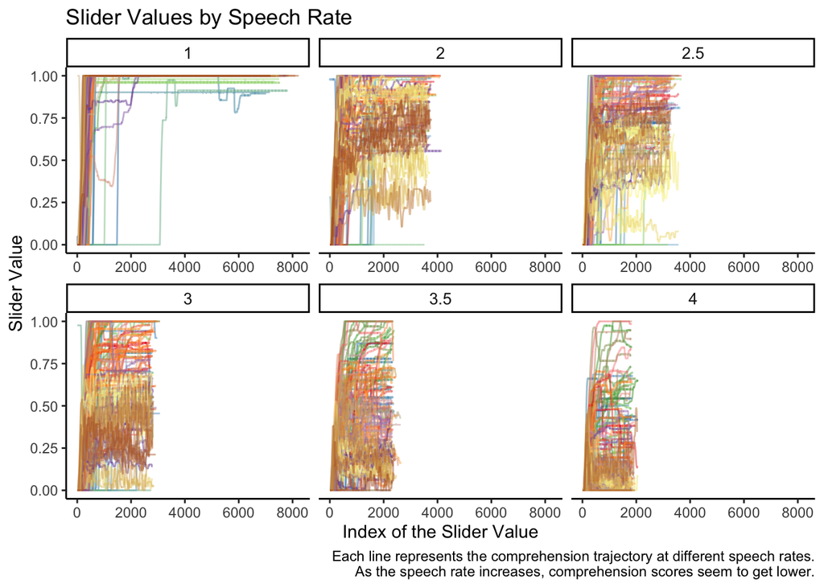

```r
# Let's visualize the slider values across speech rates
df.slider <- df.data %>%
  mutate(slider_values_rescaled = strsplit(slider_values_rescaled, ",")) %>%
  mutate(slider_rescale_float = map(slider_values_rescaled, ~as.numeric(.x)))

df_long <- df.slider %>%
  mutate(id = row_number()) %>%
  unnest(slider_rescale_float) %>%
  rename(slider_value = slider_rescale_float) %>%
  group_by(id, speech_rate) %>%
  mutate(index = row_number()) %>%
  ungroup() %>%
  select(-slider_values_rescaled)

# Set the x-axis limits
max_index <- max(df_long$index)

p_slider_per_rate <- ggplot(df_long, aes(x = index,
                                         y = slider_value,
                                         group = interaction(id),
                                         color = as.factor(id))) +
  geom_line(alpha = 0.5, size = 0.5) +
  scale_x_continuous(limits = c(0, max_index), name = "Index of the Slider Value") +
  scale_y_continuous(name = "Slider Value") +
  facet_wrap(~ speech_rate, scales = 'free_x', ncol = 3) +
  scale_color_manual(values = colorRampPalette(brewer.pal(12, "Paired"))
                     (length(unique(df_long$id)))) +
  theme(legend.position = "none") +
  labs(title = 'Slider Values by Speech Rate',
      caption = "Each line represents the comprehension trajectory at different speech rates.
      As the speech rate increases, comprehension scores seem to get lower."
)
# Make x-axis limits consistent across facets
p_slider_per_rate <- p_slider_per_rate + facet_wrap(~ speech_rate,
                                                    scales = 'free_x',
                                                    nrow = 2) +
  theme(strip.text.x = element_text(size = 10))

print(p_slider_per_rate)
```

```r
# plot the histogram of durations
```

[output not shown]

A Mixed Effects Linear Regression Analysis is conducted to model the median real-time comprehension scores. Comprehension scores of the post-hoc tests, which are the multiple-choice questions, 10-scale comprehension ratings, and summaries, are utilized as factors in the regression. Digit Span and Digit-In-Noise scores are assigned as random effects, accounting for individual subject variations. This approach allows us to explore to what degree the scores of our novel real-time comprehension measure can be explained by comprehension, above and beyond the contribution of individual differences in working memory and speech perception in noise capacities.

```r
model <- lmer(trial_median_rescaled ~
                sum_max_similarity +
                likert_response +
                multiple_choice_accuracy +
                (1 | digit_span_score) +
                (1 | digit_in_noise_score), data = df.data)
```

```
boundary (singular) fit: see help('isSingular')
```

```r
summary(model)
```

```
Linear mixed model fit by REML. t-tests use Satterthwaite's method [
lmerModLmerTest]
Formula: trial_median_rescaled ~ sum_max_similarity + likert_response +
    multiple_choice_accuracy + (1 | digit_span_score) + (1 |
    digit_in_noise_score)
   Data: df.data

REML criterion at convergence: -175.3

Scaled residuals:
    Min      1Q  Median      3Q     Max
-4.2521 -0.4291  0.1657  0.4331  2.5651

Random effects:
 Groups               Name        Variance  Std.Dev.
 digit_span_score     (Intercept) 0.0007389 0.02718
 digit_in_noise_score (Intercept) 0.0000000 0.00000
 Residual                         0.0249177 0.15785
Number of obs: 237, groups:  digit_span_score, 4; digit_in_noise_score, 3

Fixed effects:
                           Estimate Std. Error         df t value Pr(>|t|)
(Intercept)              -4.648e-04  3.627e-02  3.949e+01  -0.013    0.990
sum_max_similarity        2.122e-03  2.276e-03  1.592e+02   0.932    0.353
likert_response           9.562e-01  3.905e-02  1.850e+02  24.484   <2e-16 ***
multiple_choice_accuracy -3.263e-02  2.337e-02  2.330e+02  -1.396    0.164
---
Signif. codes:  0 '***' 0.001 '**' 0.01 '*' 0.05 '.' 0.1 ' ' 1

Correlation of Fixed Effects:
            (Intr) sm_mx_ lkrt_r
sm_mx_smlrt -0.501
likrt_rspns -0.307 -0.422
mltpl_chc_c -0.252 -0.121 -0.137
optimizer (nloptwrap) convergence code: 0 (OK)
boundary (singular) fit: see help('isSingular')
```

The working memory score accounted for a variance of 0.00074 (SD = 0.03) and the hearing-in-noise did not contribute to variance in the model. Fixed effects analysis revealed that the post-hoc likert scale values significantly predicted real-time comprehension ratings (B=0.96, SE= 0.04, t= 24.48, p<.001). However, summary and multiple choice tasks were not significantly associated with the real-time comprehension ratings. Furthermore, despite not being significant, multiple choice question accuracy seems to be negatively related to real-time comprehension, as indicated by the negative co-efficient value.

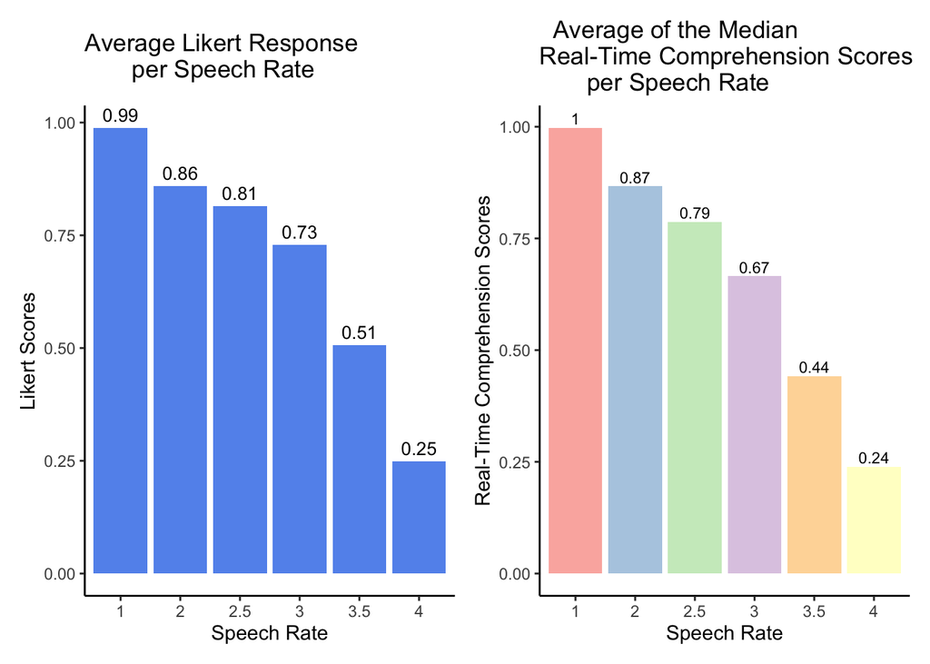

```r
# Depict the likert scale and slider values for each speech rate. Their patterns should look quite similar based on the regression analysis

# Calculate the average  likert_response scores per speech_rate category
average_likert_scores <- df.data %>%
  group_by(speech_rate) %>%
  summarise(average_likert = mean(likert_response, na.rm = TRUE))

# Plotting the average likert scale across speech rates
p1 <- ggplot(average_likert_scores, aes(x = factor(speech_rate), y = average_likert)) +
  geom_bar(stat = "identity", fill = "cornflowerblue") +
  labs(x = "Speech Rate", y = "Likert Scores", title = "Average Likert Response
       per Speech Rate") +
  geom_text(aes(label = round(average_likert, 2)), vjust = -0.5, size = 3.5)

# Calculate the average trial_median_rescaled for each speech_rate category
average_trial_median <- df.data %>%
  group_by(speech_rate) %>%
  summarise(average_trial_median = mean(trial_median_rescaled, na.rm = TRUE))

# Plot
p2 <- ggplot(average_trial_median, aes(x = factor(speech_rate), y = average_trial_median,
                                       fill = as.factor(speech_rate))) +
  geom_bar(stat = "identity", position = "dodge") +
  scale_fill_brewer(palette = "Pastel1", name = "Speech Rate") +
  labs(x = "Speech Rate", y = "Real-Time Comprehension Scores",
  title = "  Average of the Median
Real-Time Comprehension Scores
       per Speech Rate") +
  geom_text(aes(label = round(average_trial_median, 2)), vjust = -0.3,
            position = position_dodge(width = 0.9), size = 3) +
  theme(legend.position = "none")

# Arrange the plots side by side
combined_plot <- p1 + p2 + plot_layout(ncol = 2)
print(combined_plot)
```

## 4.2 Exploratory analysis

### 4.2.1 Multiple Choice Accuracy

Surprisingly, co-efficient value of multiple choice question accuracy, suggesting that wrong answers might predict successful comprehension better. Therefore, I want gain further insights into the pattern of the question measure.

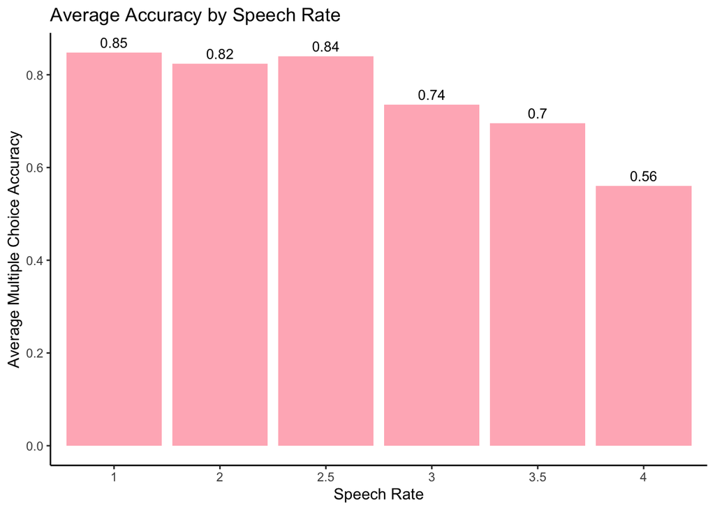

```r
# Calculate the average multiple_choice_accuracy scores per speech_rate category
average_scores <- df.data %>%
  group_by(speech_rate) %>%
  summarise(average_accuracy = mean(multiple_choice_accuracy, na.rm = TRUE))

# plot
ggplot(average_scores, aes(x = factor(speech_rate), y = average_accuracy)) +
  geom_bar(stat = "identity", fill = "lightpink") +  labs(x = "Speech Rate", y = "Average Multiple Choice Accuracy", title = "Average Accuracy by Speech Rate") +
  geom_text(aes(label = round(average_accuracy, 2)), vjust = -0.5, size = 3.5)
```

Accuracy seems quite similar between speech rates 1-2.5 despite a clear difference in comprehension reports in both real-time and post-hoc measures. Furthermore, even for the 4 times sped up condition, their performance is well above the chance level of 0.25. One possibility is that as the segments are taken from the same audiobook, despite the randomization, participants might be gaining a sense of the story and be able to guess the correct answer regardless of their ability to understand the segments. If this is the case, their average accuracy should be better in latter trials compared to earlier ones.

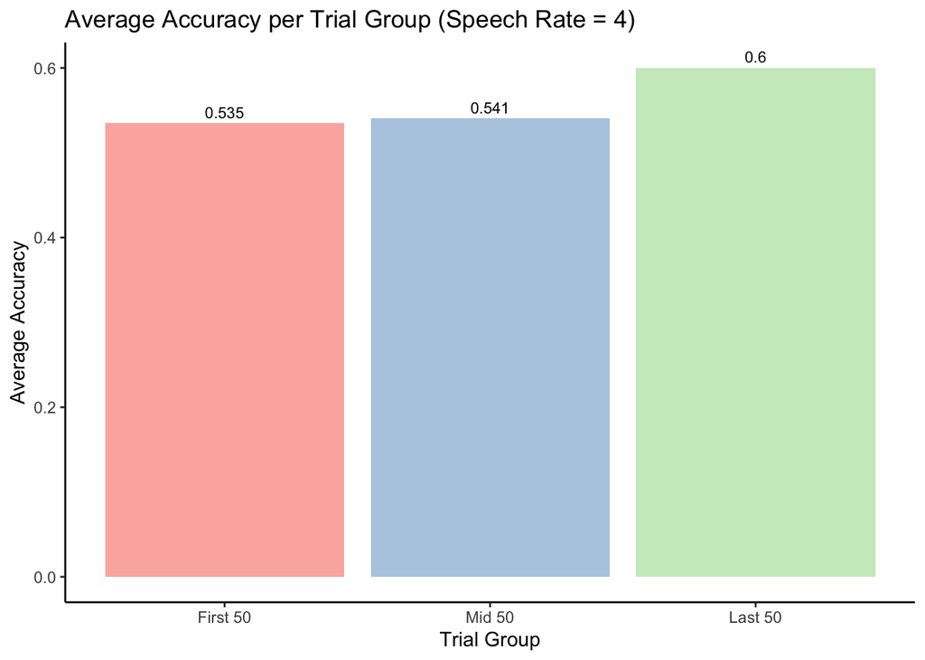

```r
# Select trials with speech rate = 4
df_data_speech_rate_4 <- df.data %>%
  filter(speech_rate == 4)

# Find out the max index number per participant to categorize last 50
max_index_numbers <- df_data_speech_rate_4 %>%
  group_by(participant) %>%
  summarise(max_index = max(index), .groups = "drop")

# Merge max_index_numbers with df_data_speech_rate_4
df_data_speech_rate_4 <- df_data_speech_rate_4 %>%
  left_join(max_index_numbers, by = "participant")

# Categorize trials into first 50, mid 50, last 50
df_data_speech_rate_4 <- df_data_speech_rate_4 %>%
  mutate(trial_group = case_when(
    index <= 50 ~ "First 50",
    index > 50 & index <= (max_index - 50) ~ "Mid 50",
    index > (max_index - 50) ~ "Last 50"
  ))

# Calculate the average multiple_choice_accuracy for each trial group
average_accuracy <- df_data_speech_rate_4 %>%
  group_by(trial_group) %>%
  summarise(average_accuracy = mean(multiple_choice_accuracy, na.rm = TRUE),
            .groups = "drop") %>%
  mutate(trial_group = factor(trial_group,
                              levels = c("First 50", "Mid 50", "Last 50"))) # order

# Plot
ggplot(average_accuracy, aes(x = trial_group, y = average_accuracy, fill = trial_group)) +
  geom_bar(stat = "identity") +
  labs(x = "Trial Group", y = "Average Accuracy",
       title = "Average Accuracy per Trial Group (Speech Rate = 4)") +
  scale_fill_brewer(palette = "Pastel1") +
  geom_text(aes(label = round(average_accuracy, 3)), vjust = -0.5, size = 3) +
  theme(legend.position = "none")
```

Question accuracy seems to get higher as participants are exposed to more trials, so there might be an effect of context familiarity. Although, even for the first 50 trials, the accuracy is way above the chance level of 0.25.

Participant performance on multiple choice questions may be influenced by the trial number they are at. If the effect of trial number on multiple choice accuracy varies over time, incorporating this interaction into the model can enhance its predictive accuracy.

```r
model_trial <- lmer(trial_median_rescaled ~
                sum_max_similarity +
                likert_response +
                multiple_choice_accuracy * index +  # Interaction between trial number and multiple_choice_accuracy
                (1 | digit_span_score) +
                (1 | digit_in_noise_score), data = df.data)
```

```
boundary (singular) fit: see help('isSingular')
```

```r
summary(model_trial)

# Compare the two models
comparison <- anova(model, model_trial)
```

```
refitting model(s) with ML (instead of REML)
```

```r
print(comparison)
```

[output not shown]

Accounting for the main effect of trial number and the interaction of multiple_choice_accuracy and trial did not yield in additional significant main effects or interaction effects. While the modified model with the interaction term hows a slightly better fit to the data in terms of log likelihood, the difference is not statistically significant (p = 0.1822). Additionally, the AIC and BIC values slightly favor the original model, suggesting that the increase in model complexity with the addition of the interaction term may not be justified given the data.

### 4.2.2 Semantic Similarity

Semantic similarity score was not a significant predictor of real-time comprehension measures.

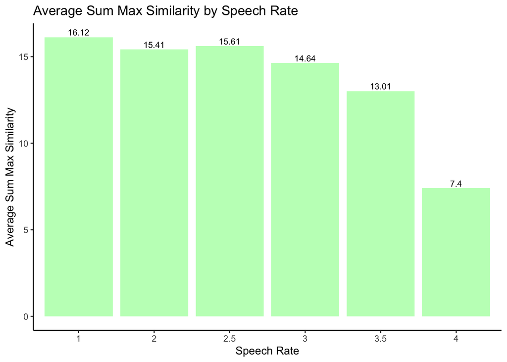

```r
# Assuming df.data is already loaded and contains the variables of interest

average_similarity <- df.data %>%
  group_by(speech_rate) %>%
  summarise(average_similarity = mean(sum_max_similarity, na.rm = TRUE))

# Plot with bars in light green
ggplot(average_similarity, aes(x = factor(speech_rate), y = average_similarity, fill = as.factor(speech_rate))) +
  geom_bar(stat = "identity", position = "dodge", fill = "darkseagreen1") +
  labs(x = "Speech Rate", y = "Average Sum Max Similarity",
       title = "Average Sum Max Similarity by Speech Rate") +
  geom_text(aes(label = round(average_similarity, 2)),
            vjust = -0.3, position = position_dodge(width = 0.9), size = 3) +
  theme(legend.position = "none")
```

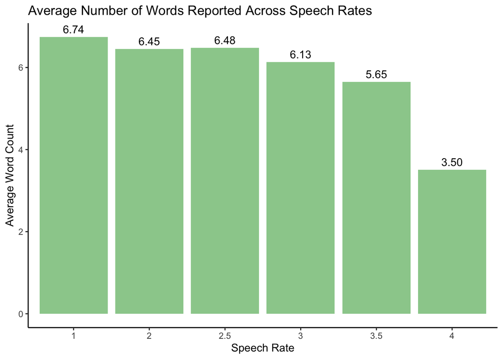

```r
#What about the number of words they reported regardless of the semantic similarity of the words?

# Calculate the number of words
df.data <- df.data %>%
  mutate(word_count = str_count(textbox.text_corrected, "\\S+") + 1)

# Aggregate data by speech rate
aggregated_data <- df.data %>%
  group_by(speech_rate) %>%
  summarize(avg_word_count = mean(word_count, na.rm = TRUE),
            .groups = 'drop')

# Plot
ggplot(aggregated_data, aes(x = as.factor(speech_rate), y = avg_word_count,
                            fill = as.factor(speech_rate))) +
  geom_bar(stat = "identity" , position = "dodge", fill = "darkseagreen3") +
  geom_text(aes(label = sprintf("%.2f", avg_word_count)), vjust = -0.5, color = "black") +
  labs(title = "Average Number of Words Reported Across Speech Rates",
       x = "Speech Rate",
       y = "Average Word Count",
       fill = "Speech Rate") +
  theme(legend.position = "none")
```

Although there is a pattern of decline as the speech rate increases, the slowest condition and 2.5 times sped up condition does not differ much. This may be due to two main reasons: number of words or concepts participants can recall is limited to their working memory capacity (especially given that they reported around 7 words maximum). Also, they only had 15 seconds to write so they might not have had enough time to report more even when they could have.

# 5 Discussion

This study proposes a novel method for assessing speech comprehension in real-time, aiming to overcome the limitations of static, post-hoc comprehension tests that often conflate comprehension with memory retention. By introducing a continuous rating system for participants listening to naturalistic speech, we aim to capture the dynamic process of comprehension as it unfolds. This approach seeks to enable the linking of behavioral data with the causal neural mechanisms of comprehension. Our hypothesis posits that scores from this real-time comprehension measure can be explained by traditional post-hoc assessments, suggesting that comprehension can be effectively measured in a dynamic manner.

Post-hoc Likert scale scores were a significant predictor of the novel comprehension measure scores, whereas summary and multiple choice question accuracy were not. Surprisingly, multiple choice question accuracy exhibited a negative coefficient value, suggesting a reverse relationship. As briefly discussed in the explanatory analysis section, there are several potential reasons for this. For the multiple choice questions, having only one question per segment does not allow for a reliable score per trial. Additionally, since all segments were taken from the same audiobook, participants might have developed a sense of the story or characters that helped them identify correct answers, even for segments they couldn’t understand. Furthermore, as both measures rely on working memory, participants could have understood the segments well but failed to recall the necessary details for the multiple choice questions, or to report more than 6-7 words for the summary task. These observations highlight the limitations of current language comprehension research methods, as both are widely used.

An alternative consideration for the summary scores is that participants were only given 15 seconds to type summaries, which may not have been sufficient time to write more, even if they could have in the slower conditions. As a next step, we plan to conduct another pilot study using only the real-time comprehension measure and the summary task. This time, we will employ the summary task for every trial and remove the 15-second time constraint. This will help us understand whether the issue is indeed related to working memory (if so, participants won’t be able to report more words even with more time) or to time limitations (if so, they should be able to report more words in slower conditions).

# 6 References

Emmorey, K., Giezen, M. R., Petrich, J. A. F., Spurgeon, E., & O’Grady Farnady, L. (2017). The relation between working memory and language comprehension in signers and speakers. Acta Psychologica, 177, 69–77. https://doi.org/10.1016/j.actpsy.2017.04.014

Gaillard, W. D., Berl, M. M., Moore, E. N., Ritzl, E. K., Rosenberger, L. R., Weinstein, S. L., Conry, J. A., Pearl, P. L., Ritter, F. F., Sato, S., Vezina, L. G., Vaidya, C. J., Wiggs, E., Fratalli, C., Risse, G., Ratner, N. B., Gioia, G., & Theodore, W. H. (2007). Atypical language in lesional and nonlesional complex partial epilepsy.

Gwilliams, L., & Davis, M. H. (2022). Extracting Language Content from Speech Sounds: The Information Theoretic Approach. In L. L. Holt, J. E. Peelle, A. B. Coffin, A. N. Popper, & R. R. Fay (Eds.), Speech Perception (Vol. 74, pp. 113–139). Springer International Publishing. https://doi.org/10.1007/978-3-030-81542-4_5

Hickok, G., & Poeppel, D. (2007). The cortical organization of speech processing. Nature Reviews Neuroscience, 8(5), 393–402. https://doi.org/10.1038/nrn2113

Peirce, J. W., Gray, J. R., Simpson, S., MacAskill, M. R., Höchenberger, R., Sogo, H., Kastman, E., Lindeløv, J. (2019). PsychoPy2: experiments in behavior made easy. Behavior Research Methods. 10.3758/s13428-018-01193-y

Pennington, J., Socher, R., Manning, C. D. (2014). GloVe: Global Vectors for Word Representation. [pdf] [bib]

Pelli, D. G. and Vale, L. (2014). Lingering pleasure in the experience of beauty. International Association for Empirical Aesthetics, New York, New York, August 22-24, 2014.

Pulvermüller, F., Shtyrov, Y., Ilmoniemi, R. J., & Marslen-Wilson, W. D. (2006). Tracking speech comprehension in space and time. NeuroImage, 31(3), 1297–1305. https://doi.org/10.1016/j.neuroimage.2006.01.030

Richardson, J. T. E. (2007). Measures of Short-Term Memory: A Historical Review. Cortex, 43(5), 635–650. https://doi.org/10.1016/S0010-9452(08)70493-3

Rohde, A., Worrall, L., Godecke, E., O’Halloran, R., Farrell, A., & Massey, M. (2018). Diagnosis of aphasia in stroke populations: A systematic review of language tests. PLOS ONE, 13(3), e0194143. https://doi.org/10.1371/journal.pone.0194143

Shannon, R. V., Zeng, F.-G., Kamath, V., Wygonski, J., & Ekelid, M. (1995). Speech Recognition with Primarily Temporal Cues. Science, 270(5234), 303–304. https://doi.org/10.1126/science.270.5234.303

Tun, P. A., Wingfield, A., & Stine, E. A. (1991). Speech-processing capacity in young and older adults: A dual-task study. Psychology and Aging, 6(1), 3–9. https://doi.org/10.1037/0882-7974.6.1.3

Wechsler, D. (1981). Wechsler Adult Intelligence Scale-Revised. Psychological Corporation, New York.

__

Gerstenberg, Tobias, Matthew F. Peterson, Noah D. Goodman, David A. Lagnado, and Joshua B. Tenenbaum. 2017. “Eye-Tracking Causality.” *Psychological Science* 28 (12): 1731–44. https://doi.org/10.1177/0956797617713053.

Grolemund, Garrett, and Hadley Wickham. 2011. “Dates and Times Made Easy with lubridate.” *Journal of Statistical Software* 40 (3): 1–25. https://www.jstatsoft.org/v40/i03/.

Müller, Kirill, and Hadley Wickham. 2023. *Tibble: Simple Data Frames*. https://tibble.tidyverse.org/.

R Core Team. 2023. *R: A Language and Environment for Statistical Computing*. Vienna, Austria: R Foundation for Statistical Computing. https://www.R-project.org/.

Spinu, Vitalie, Garrett Grolemund, and Hadley Wickham. 2023. *Lubridate: Make Dealing with Dates a Little Easier*. https://lubridate.tidyverse.org.

Wickham, Hadley. 2016. *Ggplot2: Elegant Graphics for Data Analysis*. Springer-Verlag New York. https://ggplot2.tidyverse.org.

———. 2022. *Stringr: Simple, Consistent Wrappers for Common String Operations*. https://stringr.tidyverse.org.

———. 2023a. *Forcats: Tools for Working with Categorical Variables (Factors)*. https://forcats.tidyverse.org/.

———. 2023b. *Tidyverse: Easily Install and Load the Tidyverse*. https://tidyverse.tidyverse.org.

Wickham, Hadley, Mara Averick, Jennifer Bryan, Winston Chang, Lucy D’Agostino McGowan, Romain François, Garrett Grolemund, et al. 2019. “Welcome to the tidyverse.” *Journal of Open Source Software* 4 (43): 1686. https://doi.org/10.21105/joss.01686.

Wickham, Hadley, Winston Chang, Lionel Henry, Thomas Lin Pedersen, Kohske Takahashi, Claus Wilke, Kara Woo, Hiroaki Yutani, and Dewey Dunnington. 2023. *Ggplot2: Create Elegant Data Visualisations Using the Grammar of Graphics*. https://ggplot2.tidyverse.org.

Wickham, Hadley, Romain François, Lionel Henry, Kirill Müller, and Davis Vaughan. 2023. *Dplyr: A Grammar of Data Manipulation*. https://dplyr.tidyverse.org.

Wickham, Hadley, and Lionel Henry. 2023. *Purrr: Functional Programming Tools*. https://purrr.tidyverse.org/.

Wickham, Hadley, Jim Hester, and Jennifer Bryan. 2023. *Readr: Read Rectangular Text Data*. https://readr.tidyverse.org.

Wickham, Hadley, Davis Vaughan, and Maximilian Girlich. 2023. *Tidyr: Tidy Messy Data*. https://tidyr.tidyverse.org.

Xie, Yihui. 2014. “Knitr: A Comprehensive Tool for Reproducible Research in R.” In *Implementing Reproducible Computational Research*, edited by Victoria Stodden, Friedrich Leisch, and Roger D. Peng. Chapman; Hall/CRC.

———. 2015. *Dynamic Documents with R and Knitr*. 2nd ed. Boca Raton, Florida: Chapman; Hall/CRC. https://yihui.org/knitr/.

———. 2023. *Knitr: A General-Purpose Package for Dynamic Report Generation in r*. https://yihui.org/knitr/.